# Unemployment

**NOTE**: The present notebook is coded in R. It relies heavily on the [**tidyverse**](https://www.tidyverse.org/) ecosystem of packages. We load the tidyverse below as a prerequisite for the rest of the notebook - along with a few other libraries.

$\rightarrow$ Don’t forget that code flows **sequentially**. A random chunk may not work if the previous have have not been executed.

```r
library(tidyverse)   # Package for data wrangling
library(readxl)      # Package to import MS Excel files
library(latex2exp)   # Package for LaTeX expressions
library(quantmod)    # Package for stock data extraction
library(highcharter) # Package for reactive plots
library(WDI)         # Package for World Bank data
library(ggsci)       # Package for cool color palettes
```

# Context

## Motivation

**Unemployment** is going to be a major concern in the years to come. In particular because of the **effect of AI** on the **labor market**, see for instance:

- [Canaries in the Coal Mine? Six Facts about the Recent Employment Effects of Artificial Intelligence](https://digitaleconomy.stanford.edu/publications/canaries-in-the-coal-mine/)
- [Generative AI as Seniority-Biased Technological Change: Evidence from U.S. Résumé and Job Posting Data](https://papers.ssrn.com/sol3/papers.cfm?abstract_id=5425555)

From the first paper:

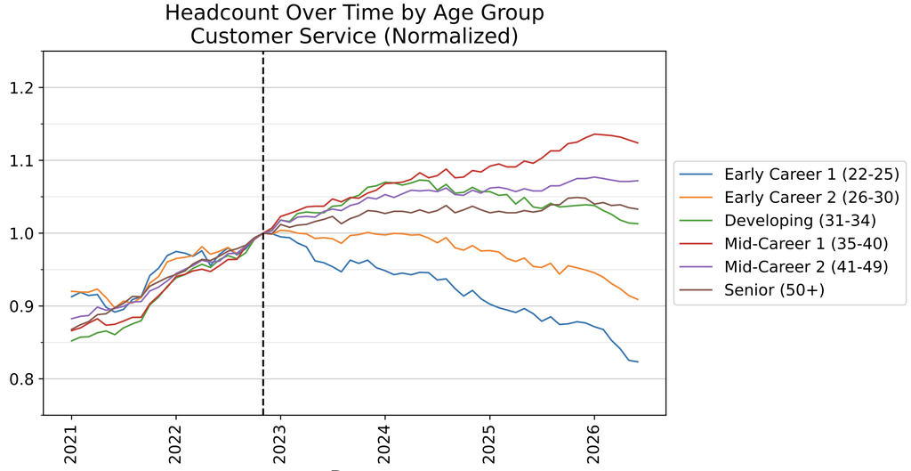

And from the second one (*Time Series of Junior and Senior Employment in Sample Firms*, normalized in 2015):

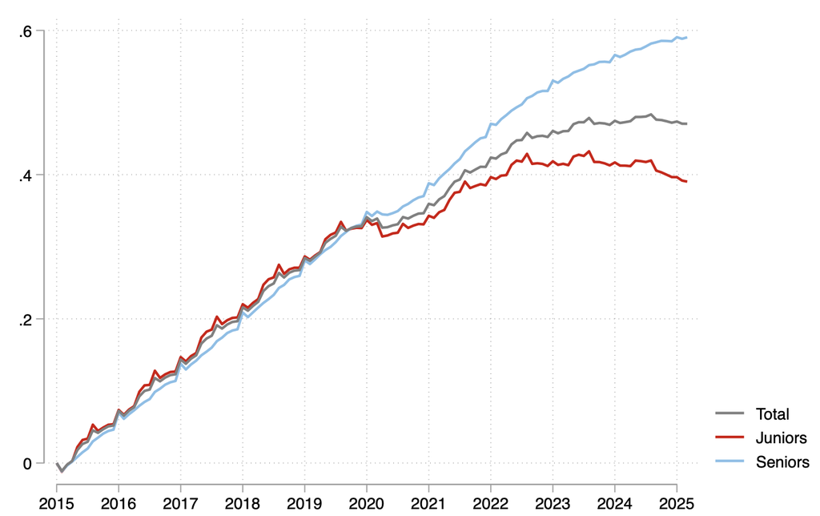

## Trends & salient facts

We first download the data from the [World Bank](https://data.worldbank.org/).

```r
wb_raw = WDI(indicator = c("unemp_advanced" = "SL.UEM.ADVN.ZS",     # Advanced education (% LF with Adv Ed.)
                           "unemp_female" = "SL.UEM.TOTL.FE.ZS",    # % of female LF
                           "unemp_male" = "SL.UEM.TOTL.MA.ZS",      # % of male LF
                           "unemp" = "SL.UEM.TOTL.ZS",
                           "pop" = "SP.POP.TOTL"
                           ),
             #country = c('FR','US'), # here you can specify some countries
             extra = TRUE,
             start = 1960,
             end = 2025) |>
  mutate(across(everything(), as.vector)) |>
  select(-status, -lending, -iso2c, -iso3c)
```

We then start with a brief **overview** over the past decades (the data starts in 1990).  
We easily identify major economic/financial shocks/events.

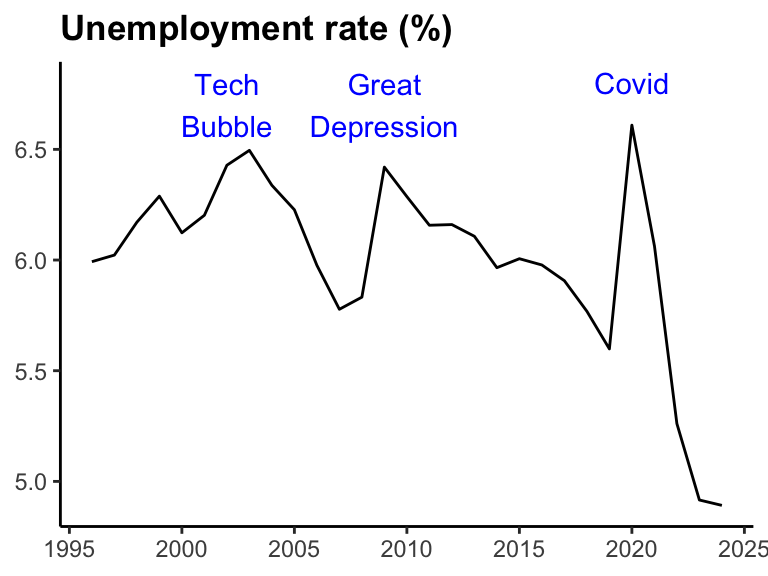

```r
wb_raw |>
  filter(country == "World", year > 1995) |>
  ggplot(aes(x = year, y = unemp)) + geom_line() +
  theme_classic() +
  theme(legend.position = c(0.2, 0.3),
        title = element_text(face = "bold"),
        legend.title = element_blank(),
        axis.title = element_blank()) +
  annotate("text", x = 2020, y = 6.8, label = "Covid", color = "blue") +
  annotate("text", x = 2009, y = 6.7, label = "Great\nDepression", color = "blue") +
  annotate("text", x = 2002, y = 6.7, label = "Tech\nBubble", color = "blue") +
  ggtitle("Unemployment rate (%)")
```

Second, let’s take a look at **gender parity**.

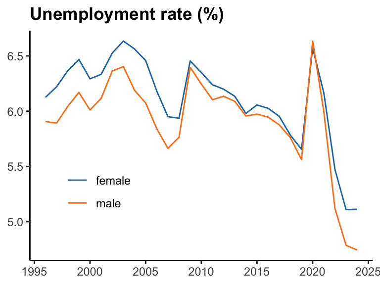

```r
wb_raw |>
  filter(country == "World", year > 1995) |>
  pivot_longer(unemp_female:unemp_male, names_to = "gender", values_to = "value") |>
  ggplot(aes(x = year, y = value, color = gender)) + geom_line() +
  theme_classic() +
  theme(legend.position = c(0.2, 0.3),
        title = element_text(face = "bold"),
        legend.title = element_blank(),
        axis.title = element_blank()) +
  scale_color_d3(labels = c("female", "male")) +
  ggtitle("Unemployment rate (%)")
```

Covid had a strong effect on the employment bias. But since then, it’s back to business-as-usual. Though, worldwide, female unemployment is at an all-time low, too.

A snapshot at the **educated** workforce (in the US this time).

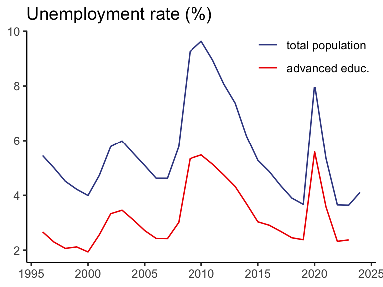

```r
wb_raw |>
  filter(country == "United States", year > 1995) |>
  pivot_longer(c(unemp_advanced,unemp), names_to = "type", values_to = "value") |>
  ggplot(aes(x = year, y = value, color = type)) + geom_line() +
  theme_classic() +
  theme(axis.title = element_blank(),
        legend.title = element_blank(),
        legend.position = c(0.82,0.89)) +
  scale_color_aaas(labels = c("total population", "advanced educ.")) +
  ggtitle("Unemployment rate (%)")
```

Education does seem worthwhile on the job market!

Finally, what about the impact of income? (mind the population-weighted average in the code)

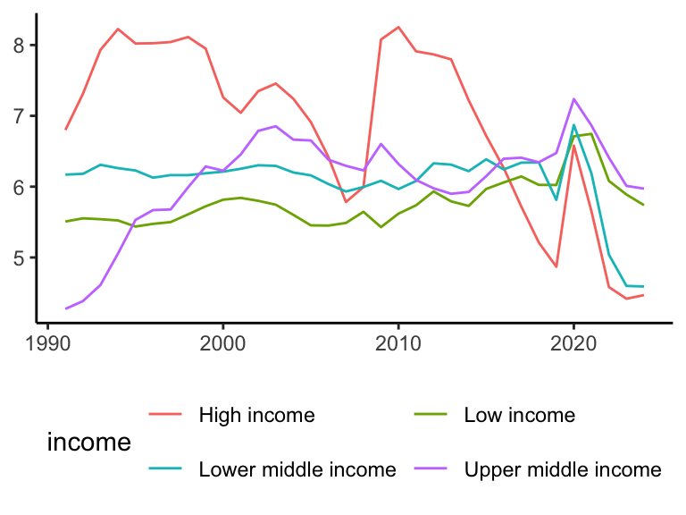

```r
wb_raw |>
  filter(year > 1980, is.finite(unemp), !(income %in% c("Aggregates", "Not classified"))) |>
  group_by(year, income) |>
  mutate(weight = pop / sum(pop)) |>
  summarise(unemp = sum(unemp * weight)) |> na.omit() |>
  ggplot(aes(x = year, y = unemp, color = income)) + geom_line() +
  theme_classic() +
  theme(axis.title = element_blank(), legend.position = "bottom") +
  guides(color=guide_legend(nrow=2,byrow=TRUE))
```

Situations have changed a lot. The rate is much more stable for lower income economies.

# A model of job search with reserve wage

A standard (the only!) reference for this section is [Search-Theoretic Models of the Labor Market: A Survey](https://www.aeaweb.org/articles?id=10.1257/002205105775362014).

## Discrete time

An agent seeks a **job** that will pay a **wage** $w$. Now, $w$ is considered to be a positive **random variable** with cumulative distribution function $F$. The agent seeks to maximize the **average discounted cash flows** she will receive:
$$\mathbb{E}\left[\sum_{t=0}^\infty \beta^t x_t \right],$$
where
$$x_t = \left\{ \begin{array}{l l} w & \text{if she takes the job} \\ b & \text{if she remains unemployed} \end{array} \right.$$
where $b$ is some constant that comes from country specific welfare programs. $\beta=(1+\rho)^{-1}\in(0,1)$ is the **discounting factor**.

The value of taking the job, if we assume that the agent takes the job **forever** (a big assumption) is
$$W(w) = w + \beta W(w),$$
where the first term comes the first wage and the second one comes from the fact that in period two, the value will remain the same, but discounted at rate $\beta$. When $w$ is fixed, the lifetime value yield exactly this result:
$$W = w \sum_{t=1}^\infty \beta^t =\frac{w}{1-\beta}.$$

The value of **not taking** the job is a bit more complex to evaluate. For the first period, the gain is $b$, but for the second period, the agent will have to choose between refusing the job again (remaining unemployed), or accepting it, hence:
$$U = b + \beta \mathbb{E}[\max(U, W(w))]. \tag{1}$$

Now, because $W$ is linearly increasing with $w$, there is a wage $w_R$, called the **reservation wage** that satisfies
$$W(w_R)=U;$$

implied that the searcher will accept the job offer if $w>w_R$ (the wage is attractive) or decline it otherwise (it’s more convenient not to work). In particular, this implies that
$$U=\frac{w_R}{1-\beta}.$$

Plugging this in Equation 1, we infer
$$\frac{w_R}{1-\beta} = b + \frac{\beta}{1-\beta}\mathbb{E}[\max(w,w_R)]$$

If we subtract $\frac{w_R\beta}{1-\beta}$ from each side, we get:

$$\begin{align}
w_R & = b + \frac{\beta(1-w_R)}{1-\beta} \int_0^\infty\max(w,w_R)dF(w) \\
& = b + \frac{\beta}{1-\beta}\left( \int_0^{w_R} w_R dF(w) + \int_{w_R}^\infty w dF(w) - w_R \right) \\
& = b + \frac{\beta}{1-\beta}\left( \int_{w_R}^\infty(w-w_R) dF(w) \right)
\end{align}$$

**NoteExpression for the reservation wage**

Finally, using **integration by part**, we reach the following expression
$$w_R=b+\frac{\beta}{1-\beta}\int_{w_R}^\infty(1-F(w))dw.$$

An interesting feature of the above expression is that $w_R$ increases with $\beta$. A small $\beta$ (preference for the present, meaning that waiting is painful) implies a **smaller reservation wage**. The searcher is more **impatient** in this case.

## Towards continuous time

If we generalize to any time step $\Delta$ with $\beta = (1+\Delta r)^{-1}$. Then, we get, for the **value of accepting**:
$$W(w) = \Delta w + \beta W(w).$$
Next, suppose that the worker gets a job offer with wage $w$ with probability $\alpha \Delta$ in each period, then the value for declining the offer is
$$U = \Delta b + \underbrace{\frac{\alpha \Delta}{1+r\Delta} \mathbb{E}[\max(U,W(w))]}_{\text{if there is an offer}} + \underbrace{\frac{(1-\alpha \Delta))}{1+r\Delta}U}_{\text{if there is no offer}}.$$
**Note**: $\alpha$ can be interpreted as a **search intensity**.
Hence, upon simplification,
$$rW(w)=(1+r\Delta)w \tag{2}$$
and
$$rU = (1+r\Delta)b + \alpha \int_0^\infty \max(0, W(w)-U)dF(w). \tag{3}$$
In the limit ($\Delta \rightarrow 0$), in **continuous time**, the objective becomes $\mathbb{E}\left[\sum_{t=0}^\infty e^{-rt} x_t \right]$ and $W=w \int_0^\infty e^{-rt}dt=w/r$ (equivalent to Equation 2). Moreover, the above equation reduces to
$$rU = b + \alpha \int_0^\infty \max(0, W(w)-U)dF(w).$$
Since, again, $W(w_R)=U$ and $W(w_R)=w_R/r$, $rU=w_R$, so
$$w_R =b+ \frac{\alpha}{r} \int_{w_R}^\infty(w-w_R)dF(w).$$
Again integrating by parts, we end up with
$$w_R = b+\frac{\alpha}{r} \int_{w_R}^\infty(1-F(w))dw.$$
Here, the **search intensity** $\alpha$ is exogenous but it could be optimized by the job seeker, modulo a cost, say $g(\alpha)$ - for instance to pay an online service to get access to more postings. The objective of the seeker is to maximize the reserve wage (minus the cost $g(\alpha)$):
$$b+\frac{\alpha}{r} \int_{w_R}^\infty(1-F(w))dw - g(\alpha). \tag{4}$$
The FOC associated to this is (differentiating w.r.t. $\alpha$):
$$\int_{w_R}^\infty(1-F(w))dw=rg'(\alpha). \tag{5}$$
The full model requires to solve Equation 4 and Equation 5.

In this model, the **duration of unemployment** can be characterized. The probability that the searcher has not found a job after time $t$ is $e^{-Ht}$ with $H=\alpha(1-F(w_R))$ being the **hazard rate**, the product of the **contract arrival rate** $(\alpha)$ and the **probability of acceptance**.

## Layoff risk

In the previous model, a job was eternal. This is unlikely in practice, especially in the modern labor market, see, e.g., in the US where turnover (employee rotation) is quite high:

- [state level separation rates from the **BLS**](https://www.bls.gov/charts/state-job-openings-and-labor-turnover/state-total-separations-rates.htm)
- [national separation rate from the **FRED**](https://fred.stlouisfed.org/series/JTSTSR)
- [**JOLTS** from the **BLS**](https://www.bls.gov/jlt/): Job Openings and Labor Turnover Survey.

Each month, ~3-4% of workers lose or change jobs.

[figure not shown]

This makes a reasonable rotation (except for Covid!).  
An important distinction being whether **departures** are **voluntary** or not…

Within the previous model, we can add a parameter that will code **job termination** (for whatever reason): $\lambda$ is the **Poisson intensity** that parametrizes the occurrence of the termination of the working contract. Hence, over a period $\Delta$, the probability of losing/changing jobs is $\lambda \Delta$.

The equivalent of Equation 2 is now

$$W(w) = \Delta w + \frac{W(w)}{1+r\Delta} (1-\lambda \Delta)+ \frac{U\lambda \Delta}{1+r\Delta}$$

Hence,
$$(1+r\Delta)W(w) = \Delta w + W(w)(1-\lambda \Delta)+U\lambda \Delta$$
and thus,
$$rW(w) = w + \lambda(U-W(w)). \tag{6}$$
The likelihood of job loss does not affect Equation 3 (there is no job to lose). This implies:
$$W(w) = \frac{w + \lambda U}{r + \lambda}. \tag{7}$$

Plus, it still holds that $U=W(w_R)=\frac{w_R+\lambda U}{r+\lambda}$, so that, again, $w_R=rU$. With Equation 3, this yields:
$$w_R= b+ \alpha \int_{0}^\infty \max\left( 0,\frac{w+\lambda U}{r+\lambda}-U \right)dF(w),$$
which is equivalent to
$$w_R = b + \frac{\alpha}{r+\lambda}\int_{w_R}^\infty (w-w_R) dF(w).$$
Hence: there is no big change, except that (a higher) $\lambda$ **reduces** the reservation wage! Indeed, if there is more **layoff uncertainty**, it is logical that the job seeker will accept a slightly **lower salary**.

## Job transitions and equilibrium unemployment

We now dig a bit deeper into the details of **turnover**. We add the new hypothesis that new job offers arrive at rate $\alpha_0$ when a worker is unemployed and at rate $\alpha_1$ when she is employed. The wage of the offer is again distributed according to $F$. Job loss still occurs at rate $\lambda$. The “value” of **unemployment** is
$$rU = b + \alpha_0 \int_{w_R}^\infty (W(w)-U)dF(w),$$
while the value of **work** reads

$$rW(w) = w + \alpha_1\int_0^\infty \max(0,W(w')-W(w))dF(w') + \lambda (U-W(w)),$$
where the integral part pertains to the choice of **switching job** (& accepting a higher wage $w'$) and the last part relates to **job loss**.

**TipSide note**

Differentiating the above equality w.r.t. $w$ leads to

$$rW'(w) = 1 - \alpha_1\left(\int_w^\infty W'(w) dF(w') \right)-\lambda W'(w),$$

i.e.,
$$W'(w)=(z+\lambda+\alpha_1(1-F(w)))^{-1}. \tag{8}$$

It still holds that $U=W(w_R)$. If we set $w=w_R$ in the above equation and combine it with the value of unemployment (the two are equal), we reach

$$w_R=b+(\alpha_0-\alpha_1)\int_{w_R}^\infty (W(w')-W(w_r))dF(w').$$
The reservation wage is attractive (compared to $b$) only if $\alpha_O>\alpha_1$: receiving offers more frequently when employed *reduces* $w_R$.

Using integration by parts as well as Equation 8, we finally reach
$$w_R = b + (\alpha_0-\alpha_1)\int_{w_R}^\infty \left(\frac{1-F(w)}{r+\lambda+\alpha_1(1-F(w))} \right)dw$$
With a few final assumptions, we can derive an **equilibrium unemployment rate**. Suppose unemployed workers find and accept a job at rate $\alpha_0 (1-F(w_R))=\alpha_0 \mathbb{P}[w>w_R]$ and employed workers lose theirs at rate $\lambda$, then the dynamics of **un**employment are given by
$$\dot{u}=\lambda (1-u) - \alpha_0(1-F(w_R))u$$

**ImportantLong-term unemployment rate**

Hence, $u$ is stable if $\dot{u}=0$, i.e., if
$$u^*=\frac{\lambda}{\lambda + \alpha_0(1-F(w_R))}.$$

Long-term unemployment decreases with $\alpha_0$, which makes perfectly sense, and increases with $\lambda$ (likelihood of losing job), which is also entirely logical.

Why not try a calibration exercise? Remember:

- $\lambda$ is job loss frequency;
- $\alpha_0$ is job arrival rate for the unemployed;
- $1-F(w_R)$ is the probability of acceptance of the reservation wage.

# Matching

This section lays out a line of thinking in the spirit of the contributions that obtained the [2010 Nobel prize](https://www.nobelprize.org/prizes/economic-sciences/2010/summary/): the **Diamond-Mortensen-Pissarides** model.

## Notations

- On the supply side of labor, let $E$ and $U$ denote the number of employed and unemployed workers so that the total labor force if $L=E+U$.
- On the demand side, the number of filled jobs is $F$ and the number of vacant ones is $V$.

Hence, the economy needs to **match** $U$ with $V$. The number of matches is modeled à la **Cobb-Douglas**,

$$M(U,V)=KU^\beta V^\gamma, \quad (\beta, \gamma) \in (0,1)^2. \tag{9}$$

We assume that when there is a match, a contract is signed, and both $U$ and $V$ are reduced by one unit.  
The variation in employed workers is then given by

$$\dot{E} = M(U,V)-bE,$$
where $b$ is an exogenous rate of job destruction. Moreover, we write

$$a_U = \frac{M(U,V)}{U}, \quad a_V = \frac{M(U,V)}{V}$$

for the rates at which **unemployed workers** find a job and at which **vacancies** are filled.

## Optimizations

Now let’s dive into the details.

### Setup

- The firm proposes a wage $w$ to the worker who derives a lifetime utility of $W(w)$ from this wage. $W$ stands for the **value of work**.
- On the other end of the contract, the firm will be able to produce an output of value $y$ from the worker and thus derive a profit of $\pi=y-w$ and we write $J=\mathbb{E}[\pi]$ for the average of this (expected) profit. $J$ is the value of the work for the firm.

If the **contract** is not signed, then the worker’s payoff (or utility) decreases to that of $U$ (as before), and for the firm, it decreases to $V$, the value of the vacancy. Hence “things will happen” only if $W>U$ and $J>V$ and this is entirely determined through $w$: the worker will of course accept an extra large salary and, on the other hand, the firm would naturally welcome worker who work for free. And this is when **bargaining** comes into play.

To blend the two utilies, we consider their product and try to solve the following program:

$$w^* = \underset{w}{\arg \max} \ (W(w)-U)^\theta (J(y-w)-V)^{1-\theta},$$
where $\theta \in (0,1)$ tunes the relative importance towards one or the other participant. It can be viewed as the **bargaining power of the worker**.

**NoteThe first order condition**

Differentiating w.r.t. $w$ to get the FOC, we reach:
$$\begin{align}
& \theta W'(w) (W(w)-U)^{\theta-1}(J(y-w)-V)^{1-\theta} \\
=& (1-\theta)J'(y-w)(W(w)-U)^\theta(J(y-w)-V)^{-\theta},
\end{align}$$

which simplifies to
$$\theta W'(w) (J(y-w)-V)= (1-\theta)J'(y-w)(W(w)-U). \tag{10}$$

### Solving the bargain

If we further assume that matches end (exogenously) at rate $\lambda$ as before, then, we get Equation 6. On the firm’s side, the value of the contract satisfies
$$J(\pi) = \Delta \pi + \frac{J(\pi)}{1+r\Delta} (1-\lambda \Delta)+ \frac{V\lambda \Delta}{1+r\Delta},$$
which translates to
$$rJ(\pi)= \pi + \lambda(V-J(\pi)),$$
i.e., exactly the same form as Equation 6. If we differentiate either of these expression w.r.t. $w$, we get: $r J'(\pi) = -\lambda J'(\pi)$, thus, $W' = J' = (r + \lambda)^{-1}.$ Substituting into Equation 10, we get:
$$\theta (J(y-w)-V) = (1-\theta) (W(w)-U),$$
i.e.,
$$W(w) = U + \theta(J(y-w)+W(w) - U - V) = U+\theta S, \tag{11}$$
with
$$S = J-V+W-U \tag{12}$$
being a **surplus**. $S$ can be interpreted as the **joint payoff** (for both the firm and the worker). Thanks to Equation 6 and its equivalent for $J$, we have that $W(w)= \frac{w+\lambda U}{r+\lambda}$ and $J = \frac{\pi+\lambda V}{r+\lambda}$. Plugging this into the above equation, the surplus equals
$$\begin{align*}
S &= \frac{\pi+\lambda V}{r+\lambda} + \frac{w+\lambda U}{r+\lambda}-U-V \\
&= \frac{y - r(U+V)}{r+\lambda}
\end{align*}$$
which is surprisingly **independent from the wage**!

Again from Equation 7 and recalling $w_R = rU$, we have that $W(w)-U= \frac{w+\lambda U}{r+\lambda}-U = \frac{w- w_R}{r+\lambda}$ and similarly
$$J-V=\frac{\pi - \pi_R}{r+\lambda},$$

with $\pi_R$ acting as **reservation** (or target) **profit** for the firm. The optimization function then becomes
$$\underset{w}{\arg \max} (w-w_R)^\theta(y-w-\pi_R)^{1-\theta}.$$

**NoteSolution for $w$**

In the end, the FOC leads to
$$w=w_R+\theta(y-\pi_R-w_R).$$

The worker will thus only accept the contract if $y>\pi_R+w_R$, that is, if her production potential exceeds the sum of reservation (wage+profit). This last part naturally comes from the objective of the firm that wants to extract sufficient value from the worker (=bargain!).

## Combining matching & bargaining

For the firm, the value of posting a vacancy is (obtained similarly as all the above examples, left as exercise here)
$$rV = -k + \alpha_V (J-V),$$

where $k$ is the cost of recruiting and $\alpha_V$ is the frequency of posting.

**NoteWe then assume a **free-entry condition**:**

There is no cost for firms to enter the market; vacancies are created until their value decreases to zero. This greatly simplifies the model, as we now have
$$\alpha_V J = k.$$

On the other side, the *value* of **unemployment** is
$$rU = b + \alpha_U(W(w)-U).$$

Combined with Equation 11, this gives
$$rU=b+\alpha_U \theta S. \tag{13}$$
We recall the expression for the **surplus**: $rU=y-(r+\lambda)S$. Equating the two yields
$$y-b = (r+\lambda + \alpha_U \theta)S, \tag{14}$$

Output minus the value of unemployment is proportional to the surplus. Now let us determine the **wage**. Equation 6 implies (subtracting $rU$ on both sides)
$$W-U=\frac{w-rU}{r+\lambda},$$
and since bargaining leads to $W-U=\theta S$ (Equation 11), it holds that
$$w-rU=(r+\lambda)\theta S.$$

But we also have from Equation 13, so that
$$w=b+\alpha_U\theta S + (r+\lambda)\theta S.$$
and
$$y-w = y - b - (\alpha_U+r+\lambda)\theta S$$

Moreover, plugging Equation 14 into the above gives
$$y-w = (r+\lambda+\alpha_U \theta)S - (\alpha_U+r+\lambda)\theta S.$$

**NoteFinally, we arrive at (upon rearranging)**

$$w = y-(r+\lambda)(1-\theta)S, \tag{15}$$
with: $\theta$ the bargaining power of the worker, $y$ her productivity, $r$ is a discounting rate (for time preference), $\lambda$ the job loss rate and $S$ the surplus (Equation 12).

## Heterogenous productivity

In the above model, matching is stylized in that we assume that each contact leads to a match and that worker productivity $(y)$ is fixed. But what if we relax this assumption and assume that $y$ is a random variable, again with distribution $F$? (though not the same as the previous one!)

In the end (See Section 4.4 of [Rogerson et al.](https://www.aeaweb.org/articles?id=10.1257/002205105775362014)), we obtain:

$$w(y) = b + \frac{\alpha_U \theta k}{\alpha_V (1-\theta)} +\theta \left(y - b - \frac{\alpha_U \theta k}{\alpha_V (1-\theta)} \right)$$
The wage is clearly associated with the productivity of the worker. If the worker has more bargaining power (higher $\theta$), then, naturally her wage increases with $y$. Here, the cost of recruiting $k$ increases the wage.

## An attempt at calibration

Can we ground these formulae into real-world data? Let’s consider Equation 15 applied to US.

- $w$: (target) **wage** - World Bank or [ILO Data](https://rshiny.ilo.org/dataexplorer39/?lang=en&segment=indicator&id=EAR_4HRL_SEX_ECO_CUR_NB_A): roughly 40$ per hour on average;
- $y$: **labor productivity** - [ILO Data](https://ilostat.ilo.org/topics/labour-productivity/): roughly 80$ per hour;
- $r$: **discount rate** - let’s say 3% annually, so 0.0015% hourly (assuming 2,000h worked);
- $\lambda$: **job loss frequency** - this one, too must be adapted to frequency, if rotation is 4% per month, this makes roughly 0.025% per hour.
- $\theta$: employee **bargaining power** - let’s assume that companies have more and set $\theta = 0.25$;
- $S$: the **surplus** - this is the big unknown.

In the end, we get:

$$40\$/h = 80\$/h - (0.0015\% + 0.025\% )/h \times 0.75 \times S \$$$

This implies $S \approx 200,000\$$, which is very high. We recall that
$$S=J-V+W-U,$$

with

- J: average expected profit (value of work for the firm);
- V: value of the vacancy (squeezed to zero);
- W: value of work for the employee;
- U: value of unemployment (idleness);